# 08_Visualizing

[윤기태 / 패스트캠퍼스] 최종 수정일 : 2018. 04. 18

## 데이터 분석을 위한 파이썬 프로그래밍 CAMP - 8회차

### *개발 환경 및 사용 라이브러리*

- 개발환경 : OSX 10.13.2, Anaconda-spyder IDE
- 개발언어 : Python 3.6.1
- 사용모듈 : pandas, numpy, matplotlib

# 1) Matplotlib 기초 실습

```python
%matplotlib inline
```

주피터 노트북에서 그래프를 그릴 때 선언해줘야 하는 명령어

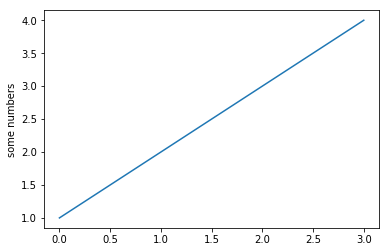

```python
import matplotlib.pyplot as plt
plt.plot([1,2,3,4])
plt.ylabel('some numbers')
plt.show()
```

plot의 default 상황에서 기준 데이터는 y임. y축의 범위는 [1,2,3,4] 이므로 1.0 ~ 4.0의 범위를 갖는 그래프가 생성됨. x축의 데이터가 없을 경우, y축의 데이터에 기반하여 동일한 모양으로 추정해주는데, 0부터 시작하기 때문에 0.0 ~ 3.0의 범위를 가짐.

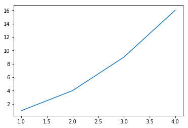

```python
plt.plot([1, 2, 3, 4], [1, 4, 9, 16])
plt.show()
```

반면, 자료를 순서대로 기입하여 명시한 경우는 위와 같은 그래프가 생성됨.

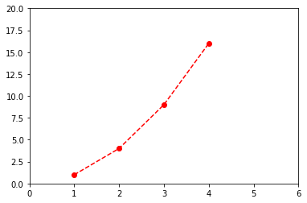

```python
plt.plot([1,2,3,4], [1,4,9,16], 'ro--') # 세번째 파라미터는 plot의 스타일과 관련된 파라미터.
plt.axis([0, 6, 0, 20])
plt.show()
```

## Line Property 컨트롤

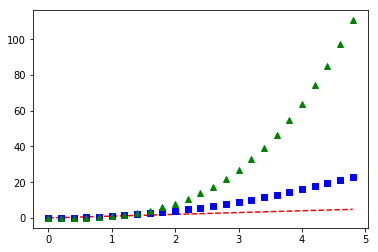

```python
import numpy as np

# numpy를 이용한 데이터 생성
t = np.arange(0., 5., 0.2)

# 파라미터를 연속적으로 3개 단위로 입력 가능
plt.plot(t, t, 'r--', t, t**2, 'bs', t, t**3, 'g^')
plt.show()
```

plot 함수 안에 파라미터를 연속적으로 입력해서 다양한 그래프 생성 가능. 그래프 스타일 파라미터로 다르게 나타내는 것도 가능.

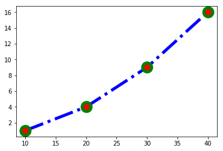

```python
plt.plot([10, 20, 30, 40], [1, 4, 9, 16], c="b",
         lw=5, ls="-.", marker="o", ms=15, mec="g", mew=5, mfc="r")
plt.show()
```

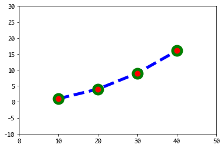

```python
plt.plot([10, 20, 30, 40], [1, 4, 9, 16],
         c="b", lw=5, ls="--", marker="o", ms=15, mec="g", mew=5, mfc="r")
plt.axis([0, 50, -10, 30])
plt.show()
```

다양한 파라미터로 세부적인 디자인 조절이 가능. 자세한 내용은 pdf 슬라이드 참고.

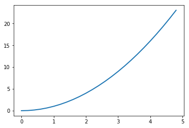

```python
plt.plot(t, t**2, linewidth=2.0)
```

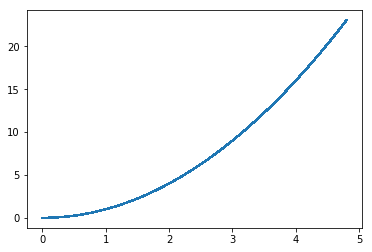

```python
line, = plt.plot(t, t**2, '-')
line.set_antialiased(False) # 안티 앨리어싱 해제
```

[output not shown]

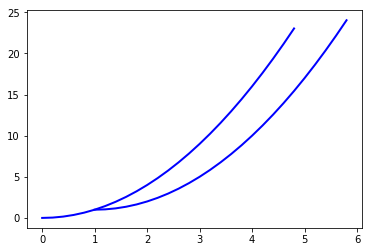

```python
lines = plt.plot(t, t**2, t+1, t**2 + 1)
plt.setp(lines, color='r', linewidth=2.0)
plt.setp(lines, 'color', 'b', 'linewidth', 2.0)
```

setp 함수를 통해 이미 그려진 라인 스타일에 덮어쓰기 가능. 함수 파라미터를 비워둘 경우, 이미 그려진 그래프의 정보를 가져옴.

```python
plt.setp(lines)
```

```
  agg_filter: a filter function, which takes a (m, n, 3) float array and a dpi value, and returns a (m, n, 3) array
  alpha: float (0.0 transparent through 1.0 opaque)
  animated: bool
  antialiased or aa: [True | False]
  clip_box: a `~.Bbox` instance
  clip_on: bool
  clip_path: [(`~matplotlib.path.Path`, `~.Transform`) | `~.Patch` | None]
  color or c: any matplotlib color
  contains: a callable function
  dash_capstyle: ['butt' | 'round' | 'projecting']
  dash_joinstyle: ['miter' | 'round' | 'bevel']
  dashes: sequence of on/off ink in points
  drawstyle: ['default' | 'steps' | 'steps-pre' | 'steps-mid' | 'steps-post']
  figure: a `~.Figure` instance
  fillstyle: ['full' | 'left' | 'right' | 'bottom' | 'top' | 'none']
  gid: an id string
  label: object
  linestyle or ls: ['solid' | 'dashed', 'dashdot', 'dotted' | (offset, on-off-dash-seq) | ``'-'`` | ``'--'`` | ``'-.'`` | ``':'`` | ``'None'`` | ``' '`` | ``''``]
  linewidth or lw: float value in points
  marker: :mod:`A valid marker style <matplotlib.markers>`
  markeredgecolor or mec: any matplotlib color
  markeredgewidth or mew: float value in points
  markerfacecolor or mfc: any matplotlib color
  markerfacecoloralt or mfcalt: any matplotlib color
  markersize or ms: float
  markevery: [None | int | length-2 tuple of int | slice | list/array of int | float | length-2 tuple of float]
  path_effects: `~.AbstractPathEffect`
  picker: float distance in points or callable pick function ``fn(artist, event)``
  pickradius: float distance in points
  rasterized: bool or None
  sketch_params: (scale: float, length: float, randomness: float)
  snap: bool or None
  solid_capstyle: ['butt' | 'round' |  'projecting']
  solid_joinstyle: ['miter' | 'round' | 'bevel']
  transform: a :class:`matplotlib.transforms.Transform` instance
  url: a url string
  visible: bool
  xdata: 1D array
  ydata: 1D array
  zorder: float
```

## 화면 분할과 그리드 기능

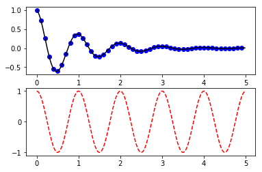

```python
def f(t):
    return np.exp(-t) * np.cos(2*np.pi*t)

t1 = np.arange(0.0, 5.0, 0.1)
t2 = np.arange(0.0, 5.0, 0.02)

plt.figure(1)
plt.subplot(211)
plt.plot(t1, f(t1), 'bo', t2, f(t2), 'k')

plt.subplot(212)
plt.plot(t2, np.cos(2*np.pi*t2), 'r--')
plt.show()
```

여러 개의 그래프를 선언해놓고, show 함수를 사용하면 한번에 비교가 가능

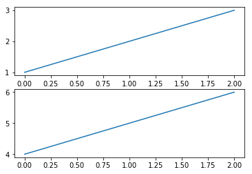

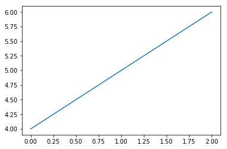

```python
plt.figure(1) # 그림 번호
plt.subplot(211) # subplot : 그리드 번호
plt.plot([1, 2, 3])
plt.subplot(212)
plt.plot([4, 5, 6])

plt.figure(2)
plt.plot([4, 5, 6])
plt.show()
```

subplot 그리드 예시

- 111 : 1x1그리드에 첫 번째 subplot
- 234 : 2x3그리드에 네 번째 subplot
- nml : nxm그리드에 l번째 subplot

## 텍스트 활용하기

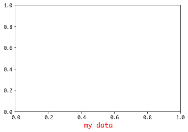

```python
t = plt.xlabel('my data', fontsize=14, color='red')
```

[output not shown]

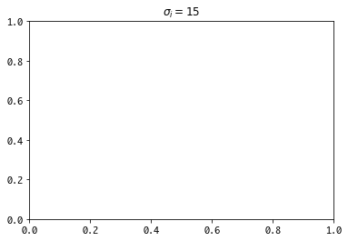

```python
plt.title(r'$\sigma_i=15$') # 수학 기호 사용하는 법
```

```
[ 101.23239375  105.09111469  107.45785532 ...,   98.30667782   89.17739217
   88.76542422]
```

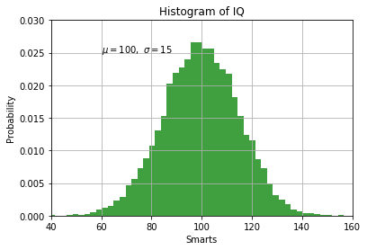

```python
mu, sigma = 100, 15
x = mu + sigma * np.random.randn(10000)
print(x)

# 히스토그램 그리기
plt.hist(x, 50, normed=True, facecolor='g', alpha=0.75)
plt.plot(x)

plt.xlabel('Smarts')
plt.ylabel('Probability')
plt.title('Histogram of IQ')
plt.text(60, .025, r'$\mu=100,\ \sigma=15$')
plt.axis([40, 160, 0, 0.03])
plt.grid(True)
plt.show()
```

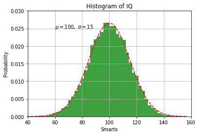

```python
import matplotlib.mlab as mlab

n, bins, patches = plt.hist(x, 50, normed=True, facecolor='g', alpha=0.75)
plt.plot(x)

plt.xlabel('Smarts')
plt.ylabel('Probability')
plt.title('Histogram of IQ')
plt.text(60, .025, r'$\mu=100,\ \sigma=15$')
plt.axis([40, 160, 0, 0.03])
plt.grid(True)

# add a 'best fit' line
y = mlab.normpdf(bins, mu, sigma)
plt.plot(bins, y, 'r--')
plt.show()
```

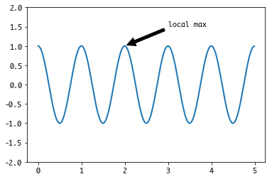

```python
ax = plt.subplot(111)

t = np.arange(0.0, 5.0, 0.01)
s = np.cos(2*np.pi*t)
line, = plt.plot(t, s, lw=2)

plt.annotate('local max', xy=(2, 1), xytext=(3, 1.5),
            arrowprops=dict(facecolor='black', shrink=0.05),
            )

plt.ylim(-2,2)
plt.show()
```

annotate 함수로 강조 표시 그리기. 실제 좌표와 텍스트 좌표를 입력하여 생성 가능.

## 한글 사용하기

```python
import matplotlib as mpl
set(sorted([f.name for f in mpl.font_manager.fontManager.ttflist])) # 현재 OS 내에 설치된 폰트 확인
```

```
{'.Keyboard',
 '.LastResort',
 '.SF Compact Display',
 '.SF Compact Rounded',
 '.SF Compact Text',
 '.SF NS Display Condensed',
 '.SF NS Text Condensed',
 '08SeoulHangang',
 '08SeoulNamsan',
 'Andale Mono',
 'Apple Braille',
 'Apple Chancery',
 'Apple Symbols',
 'AppleGothic',
 'AppleMyungjo',
 'Arial',
 'Arial Black',
 'Arial Narrow',
 'Arial Rounded MT Bold',
 'Arial Unicode MS',
 'Avenir Next LT Pro',
 'Ayuthaya',
 'Big Caslon',
 'Bodoni 72 Smallcaps',
 'Bodoni Ornaments',
 'Bradley Hand',
 'Brush Script MT',
 'Chalkduster',
 'Comic Sans MS',
 'Courier New',
 'DIN Alternate',
 'DIN Condensed',
 'Daum',
 'DejaVu Sans',
 'DejaVu Sans Display',
 'DejaVu Sans Mono',
 'DejaVu Serif',
 'DejaVu Serif Display',
 'Diwan Thuluth',
 'Farisi',
```

[output cut: 47 more lines]

```
 'YDIPinoM',
 'YDIYGO310',
 'YDIYGO320',
 'YDIYGO330',
 'YDIYGO340',
 'YDIYGO350',
 'Zapf Dingbats',
 'Zapfino',
 'cmb10',
 'cmex10',
 'cmmi10',
 'cmr10',
 'cmss10',
 'cmsy10',
 'cmtt10'}
```

한글폰트가 없다면, http://hangeul.naver.com/2017/nanum 에서 설치

```python
mpl.rc('font', family='08SeoulHangang') # 각자 OS에 존재하는 한글폰트를 선택하면 됨. 없는경우 위의 링크에서 나눔폰트 다운로드 후 실행
mpl.rc('axes', unicode_minus=False)
```

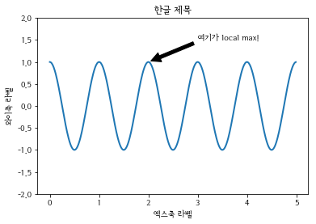

```python
plt.title('한글 제목')
plt.xlabel("엑스축 라벨")
plt.ylabel("와이축 라벨")

t = np.arange(0.0, 5.0, 0.01)
s = np.cos(2*np.pi*t)
line, = plt.plot(t, s, lw=2)

plt.annotate('여기가 local max!', xy=(2, 1), xytext=(3, 1.5),
            arrowprops=dict(facecolor='black', shrink=0.05),
            )

plt.ylim(-2,2)
plt.show()
```

## 범례 추가하기

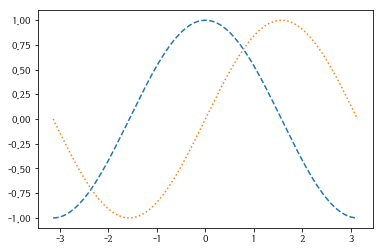

```python
X = np.linspace(-np.pi, np.pi, 256)
C, S = np.cos(X), np.sin(X)
plt.plot(X, C, ls="--", label="cosine") # 라벨을 붙여줬지만 legend 함수가 없으므로 범례는 보이지 않음
plt.plot(X, S, ls=":", label="sine")
plt.show()
```

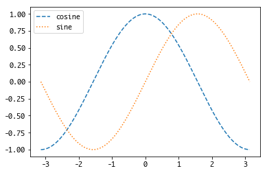

```python
X = np.linspace(-np.pi, np.pi, 256)
C, S = np.cos(X), np.sin(X)
plt.plot(X, C, ls="--", label="cosine")
plt.plot(X, S, ls=":", label="sine")
plt.legend(loc=2) # 범례 설정하는 부분
plt.show()
```

## Ticks, 내부그리드 설정하기

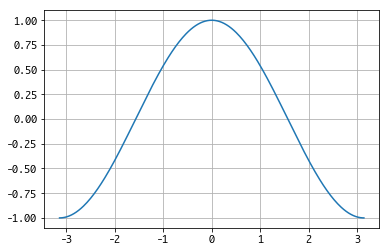

```python
X = np.linspace(-np.pi, np.pi, 256)
C = np.cos(X)
plt.plot(X, C)
plt.grid(True)
plt.show()
```

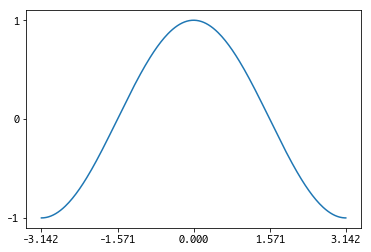

```python
X = np.linspace(-np.pi, np.pi, 256)
C = np.cos(X)
plt.plot(X, C)
plt.xticks([-np.pi, -np.pi / 2, 0, np.pi / 2, np.pi])
plt.yticks([-1, 0, +1])
plt.grid(False)
plt.show()
```

default의 경우, 알아서 ticks를 설정해 주지만 이렇게 수동으로 설정이 가능.

## pie chart 그리기

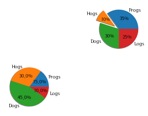

```python
import matplotlib.pyplot as plt
from matplotlib.gridspec import GridSpec

# 시각화할 데이터
labels = 'Frogs', 'Hogs', 'Dogs', 'Logs'
fracs1 = [15, 30, 45, 10]
fracs2 = [35, 10, 30, 25]

explode = (0, 0.25, 0, 0)

the_grid = GridSpec(2, 2)
plt.subplot(the_grid[1, 0], aspect=1)
plt.pie(fracs1, labels=labels, autopct='%1.1f%%', shadow=True)
plt.subplot(the_grid[0, 1], aspect=1)
plt.pie(fracs2, explode=explode, labels=labels, autopct='%.0f%%', shadow=True)

plt.show()
```

## 예제 정답

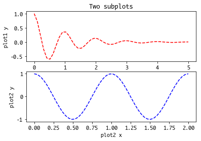

```python
x1 = np.linspace(0.0, 5.0)
x2 = np.linspace(0.0, 2.0)
y1 = np.cos(2 * np.pi * x1) * np.exp(-x1)
y2 = np.cos(2 * np.pi * x2)

ax1 = plt.subplot(2, 1, 1)
plt.plot(x1, y1, 'r--')
plt.title('Two subplots')
plt.ylabel('plot1 y')

ax2 = plt.subplot(2, 1, 2)
plt.plot(x2, y2, 'b--')
plt.xlabel('plot2 x')
plt.ylabel('plot2 y')

plt.show()
```